# Introduction to Text Mining

## Preliminaries

Before proceeding, let us run the script below:

```r
library(tidyverse)
```

We will be working as well with R packages that contains text data we will be analyzing for this class. Here are some basic information about text source packages we will be working with:

- `janeaustenr` contains data from Jane Austen’s 6 completed books.
- `gutenbergr` allows you to download text/book data collected in the Gutenberg Project( https://www.gutenberg.org/)

So make sure to run the following scripts:

```r
# Uncomment and run if needed
# install.packages("janeaustenr")
# install.packages("gutenbergr")
```

## What is tidy data?

Throughout this semester, we have been working what is called **tidy data**. There are plenty of definitions for what constitutes **tidy data** and frankly, I’ll avoid specifying any of them since the definitions are somewhat imperfect.

But here’s the point of **tidy data**: some data formats are easier to work with given tools we use.

Let us consider `table2` below:

```r
data("table2")
head(table2)
```

```
# A tibble: 6 × 4
  country      year type           count
  <chr>       <dbl> <chr>          <dbl>
1 Afghanistan  1999 cases            745
2 Afghanistan  1999 population  19987071
3 Afghanistan  2000 cases           2666
4 Afghanistan  2000 population  20595360
5 Brazil       1999 cases          37737
6 Brazil       1999 population 172006362
```

Look at the table above. Suppose we are interested in calculating `case_rate` (defined as cases/population). There is no easy way to calculate `case_rate` for the format above but now let us consider `table1` below:

```r
data("table1")
head(table1)
```

```
# A tibble: 6 × 4
  country      year  cases population
  <chr>       <dbl>  <dbl>      <dbl>
1 Afghanistan  1999    745   19987071
2 Afghanistan  2000   2666   20595360
3 Brazil       1999  37737  172006362
4 Brazil       2000  80488  174504898
5 China        1999 212258 1272915272
6 China        2000 213766 1280428583
```

`table1` is a lot easier to work with and given the format above, we can simply use `mutate()` to compute `case_rate:`

```r
table1 |>
  mutate(case_rate = cases/population)
```

```
# A tibble: 6 × 5
  country      year  cases population case_rate
  <chr>       <dbl>  <dbl>      <dbl>     <dbl>
1 Afghanistan  1999    745   19987071 0.0000373
2 Afghanistan  2000   2666   20595360 0.000129
3 Brazil       1999  37737  172006362 0.000219
4 Brazil       2000  80488  174504898 0.000461
5 China        1999 212258 1272915272 0.000167
6 China        2000 213766 1280428583 0.000167
```

## What is tidy text data?

Tidy text format is defined as being **a table with one-token-per-row.**

Therefore, if the unit of analysis we are doing is focused on a single word, then our token is a single word. Therefore, **one-token-per-row** in a single word focus analysis means **one-token-per-row**.

**Your book defines token as:** A token is a meaningful unit of text, most often a word, that we are interested in using for further analysis, and tokenization is the process of splitting text into tokens.

## Example of non-tidy text data

Suppose we want to analyze word counts (so token is a single word) and we are given a non-tidy text data frame or table named `lincoln_memorial_df` for this analysis which includes the inscription from the Lincoln Memorial which you may access from https://www.nps.gov/linc/learn/historyculture/inscriptions.htm

Let us run the script below to demonstrate an example of a non-tidy text data frame:

```r
# The point here is not to know how to create data frame from scratch but to emphasize what a non tidy text data looks like, so focus on the output only
lincoln_memorial_df <- tibble(line = 1:5,
                              text = c("In This Temple ...",
                                       "As In The Hearts Of The People ...",
                                       "For Whom He Saved The Union ...",
                                       "For Memory Of Abraham Lincoln ...",
                                       "Is Enshrined Forever ..."))

lincoln_memorial_df
```

```
# A tibble: 5 × 2
   line text
  <int> <chr>
1     1 In This Temple ...
2     2 As In The Hearts Of The People ...
3     3 For Whom He Saved The Union ...
4     4 For Memory Of Abraham Lincoln ...
5     5 Is Enshrined Forever ...
```

## Working with the tidytext package

Before working further with text parsing, let us install then load the tidy text page by running the script below:

```r
# run in console if not installed:
# install.packages("tidytext")
library(tidytext)
```

One of the processes we will be doing with tidytext is called **tokenization** which is defined as the formal process of breaking down text data into individual tokens.

Before proceeding with the tokenization process, let us look at sample data from `lincoln_memorial_df`

```r
head(lincoln_memorial_df)
```

```
# A tibble: 5 × 2
   line text
  <int> <chr>
1     1 In This Temple ...
2     2 As In The Hearts Of The People ...
3     3 For Whom He Saved The Union ...
4     4 For Memory Of Abraham Lincoln ...
5     5 Is Enshrined Forever ...
```

## unnest_tokens() to create tokens

`tidytext`’s `unnest_token()` is the primary tool or function to create tokens.

You should pipe your table or data frame into:

`unnest_token(output = word,`

`input = [the name of your text variable/column here]).`

The argument `output = word` tells `unnest_tokens()` that you want single-word tokens.

Since `text` is the column or variable name from `lincoln_memorial_df` that we want to tokenize, we need to set `input = text` as demonstrated in the R chunk below.

Before running the script below, think of this question before running the script: besides creating rows for each word, what else did the tokenization process do to our words? After reading the question, run the script below:

```r
lincoln_memorial_df |>
  unnest_tokens(output = word, input = text)
```

```
# A tibble: 24 × 2
    line word
   <int> <chr>
 1     1 in
 2     1 this
 3     1 temple
 4     2 as
 5     2 in
 6     2 the
 7     2 hearts
 8     2 of
 9     2 the
10     2 people
# ℹ 14 more rows
```

.

.

.

.

.

.

.

**Question:** Besides creating rows for each word, what else did the tokenization process do to our words? By default, `unnest_token()` will do the following:

**Answer:**

- Other columns are retained (e.g., in our example, `line` was kept)
- Punctuations or symbols (e.g., `...` at the end of the phrase) are stripped.
- Converts all text data into lower-case.

## Analyzing text of Jane Austen’s books

Some descriptive analysis of data from the `janeaustenr` package:

```r
library(janeaustenr)

# properly saves the data as an R object in your R environment
austen_books <- austen_books()

# view sample of data
head(austen_books, 10)
```

```
# A tibble: 10 × 2
   text                    book
   <chr>                   <fct>
 1 "SENSE AND SENSIBILITY" Sense & Sensibility
 2 ""                      Sense & Sensibility
 3 "by Jane Austen"        Sense & Sensibility
 4 ""                      Sense & Sensibility
 5 "(1811)"                Sense & Sensibility
 6 ""                      Sense & Sensibility
 7 ""                      Sense & Sensibility
 8 ""                      Sense & Sensibility
 9 ""                      Sense & Sensibility
10 "CHAPTER 1"             Sense & Sensibility
```

```r
# what books are included and how many lines/rows for each book?
austen_books |>
  group_by(book) |>
  summarize(number_lines = n())
```

```
# A tibble: 6 × 2
  book                number_lines
  <fct>                      <int>
1 Sense & Sensibility        12624
2 Pride & Prejudice          13030
3 Mansfield Park             15349
4 Emma                       16235
5 Northanger Abbey            7856
6 Persuasion                  8328
```

Sometimes, `head()` can be not so informative. So here’s a way to randomly view a sample of your data using `sample_n()`, a tool from the tidyverse package:

```r
# Randomly prints 10 rows (this will change everytime you run this)
austen_books |>
  sample_n(10)
```

```
# A tibble: 10 × 2
   text                                                                    book
   <chr>                                                                   <fct>
 1 "refusal which his cousin had steadfastly given him would naturally fl… Prid…
 2 "Bates should never again--no, never! If attention, in future, could d… Emma
 3 "\"One observation may, I think, be fairly drawn from the whole of the" Sens…
 4 "I am heartily glad to hear you say the same. But I have a notion, Mis… Nort…
 5 "know.\""                                                               Prid…
 6 "them at the rooms.\""                                                  Nort…
 7 "received as a relation again, that their former good understanding wa… Pers…
 8 "\"We see things very differently,\" cried Maria. \"I am perfectly"     Mans…
 9 "occupier of that interesting division of a family in which she had"    Mans…
10 "was ten years before; and, generally speaking, if there has been"      Pers…
```

## **Creating word counts: tokenization**

If we want to create word counts, tokens have to be the individual words. Therefore, our tokenization has to yield individual words as token (again, set `output = word` within `unnest_tokens()`).

Now let us tokenize `austen_books` and save the resulting tidy text data frame as `austen_books_tidy`:

```r
austen_books_tidy <- austen_books |>
  unnest_tokens(output = word, input = text)

austen_books_tidy |>
  head(10)
```

```
# A tibble: 10 × 2
   book                word
   <fct>               <chr>
 1 Sense & Sensibility sense
 2 Sense & Sensibility and
 3 Sense & Sensibility sensibility
 4 Sense & Sensibility by
 5 Sense & Sensibility jane
 6 Sense & Sensibility austen
 7 Sense & Sensibility 1811
 8 Sense & Sensibility chapter
 9 Sense & Sensibility 1
10 Sense & Sensibility the
```

Again, the purpose of tokenization is to create a data format that we can easily process for further tasks.

Now, `austen_books_tidy` is a data type we can easily work with for word counts–this is now in a tidy text data format. It is in a format that works with `summarize()`.

Now, suppose we want to do an analysis for the **top 10 words** present within `austen_books_tidy`. Before running the script below, ask yourselves: do the top 10 words presented yield any meaningful insight? After reading this question, run the script below:

```r
# preliminary code: not final, we can improve this further
austen_books_tidy |>
  group_by(word) |>
  summarize(n = n()) |>
  arrange(desc(n)) |>
  head(10)
```

```
# A tibble: 10 × 2
   word      n
   <chr> <int>
 1 the   26351
 2 to    24044
 3 and   22515
 4 of    21178
 5 a     13408
 6 her   13055
 7 i     12006
 8 in    11217
 9 was   11204
10 it    10234
```

.

.

.

.

.

.

**Question:** Do the top 10 words presented yield any meaningful insight?

**Answer:** No. These common ‘filler’ words (e.g., “the”, “of”, “to”) are not meaningful. These words are commonly referred to as stop words.

Stop words are formally defined as **commonly used words such as articles, pronouns and prepositions.** We typically remove these words in common and simple text analysis or natural language processing (NLP) tasks.

Within tidytext, there is a built-in dataset called `stop_words` that we can leverage to **REMOVE** stop words. Here’s a quick preview of stop_words before we use it:

```r
data("stop_words")
head(stop_words)
```

```
# A tibble: 6 × 2
  word      lexicon
  <chr>     <chr>
1 a         SMART
2 a's       SMART
3 able      SMART
4 about     SMART
5 above     SMART
6 according SMART
```

**How do we fix our preliminary code with stop words?**

Again, let us quickly view the incorrect code before fixing it:

```r
# preliminary code: not final, we can improve this further
austen_books_tidy |>
  group_by(word) |>
  summarize(n = n()) |>
  arrange(desc(n)) |>
  head(10)
```

```
# A tibble: 10 × 2
   word      n
   <chr> <int>
 1 the   26351
 2 to    24044
 3 and   22515
 4 of    21178
 5 a     13408
 6 her   13055
 7 i     12006
 8 in    11217
 9 was   11204
10 it    10234
```

Below implements a simple fix by piping `austen_books_tidy` into `anti_join(stop_words)` before the `group_by()` statement. `anti_join(stop_words)` effectively removes tokens when the words are found in `stop_words` (in other words, stop words are removed)

```r
# corrected to remove stop words
# added anti_join(stop_words) to remove the stop words using stop_words as a reference guide
austen_books_tidy |>
  anti_join(stop_words) |> #
  group_by(word) |>
  summarize(n = n()) |>
  arrange(desc(n)) |>
  head(20)
```

```
# A tibble: 20 × 2
   word          n
   <chr>     <int>
 1 miss       1855
 2 time       1337
 3 fanny       862
 4 dear        822
 5 lady        817
 6 sir         806
 7 day         797
 8 emma        787
 9 sister      727
10 house       699
11 elizabeth   687
12 elinor      623
13 hope        601
14 friend      593
15 family      578
16 mind        563
17 father      558
18 home        550
19 jane        550
20 mother      541
```

## Quick note and detour on anti_join()

If you want a more technical explanation of `anti_join()`, DATA 412/612 (Statistical Programming in R) teaches an entire class on joins alone (see slide 22 of my lecture on joins from a course I taught last semester: https://jmtfeliciano.github.io/DATA412Fall2024/Data412612Lecture7#22).

But all you need to know for this class is that you will often have to pipe your tidy text table or data into `anti_join(stop_words)` before further analysis to remove the stop words–that is all you need to really know for this class.

But if you want to visualize a simpler example, let us quickly run the script below:

```r
tableA <- tibble(word = c("A", "B", "C"))
tableB <- tibble(word = c("B", "D", "Z"))

tableA
```

```
# A tibble: 3 × 1
  word
  <chr>
1 A
2 B
3 C
```

```r
tableB
```

```
# A tibble: 3 × 1
  word
  <chr>
1 B
2 D
3 Z
```

Since word = B is present in both tableA and tableB, word = B is removed from TableA before being saved as `new_table`:

```r
new_table <- tableA |>
  anti_join(tableB)
new_table
```

```
# A tibble: 2 × 1
  word
  <chr>
1 A
2 C
```

**Detour complete!** Now let us go back to actual text analysis!

## Plotting top words

Before proceeding, let us actually save the table or data frame we previewed into a proper R object. Let us call it `austen_top10`:

```r
austen_top10 <- austen_books_tidy |>
  anti_join(stop_words) |>
  group_by(word) |>
  summarize(n = n()) |>
  arrange(desc(n)) |>
  head(10)
austen_top10
```

```
# A tibble: 10 × 2
   word       n
   <chr>  <int>
 1 miss    1855
 2 time    1337
 3 fanny    862
 4 dear     822
 5 lady     817
 6 sir      806
 7 day      797
 8 emma     787
 9 sister   727
10 house    699
```

With `austen_top10` created, we can use `ggplot()` with `geom_col()`. Let us consider the two images below with the second one being the better one you should always create.

The first image uses the simple/default code you’d probably write for ggplot:

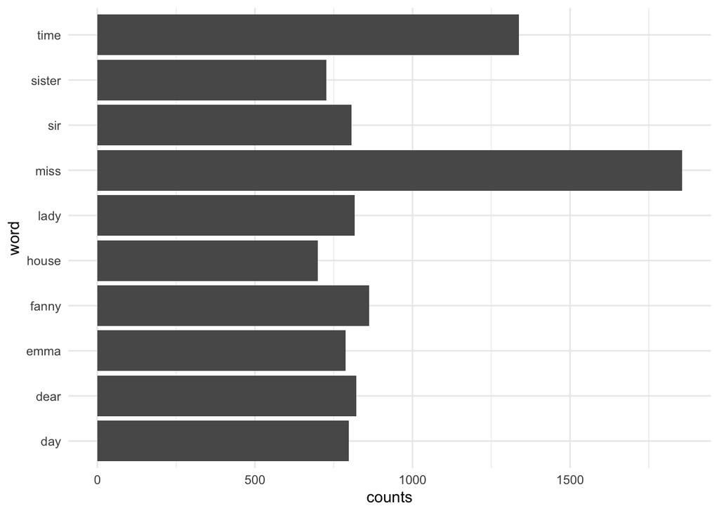

```r
# first image: unordered
ggplot(austen_top10, aes(x = n, y = word)) +
  geom_col() +
  theme_minimal() +
  labs(x = "counts", y = "word")
```

The second image uses `fct_reorder()` to tell R you want it to order image by some tally. `y = fct_reorder(word, n)` tells R or ggplot that you want `word` to be displayed in the y-axis but you want them ordered based on the value of `n` (which represents count). Note: DATA 412/612 delves deeply into `fct_reorder()` which is from tidyverse’s `forcats` package. The resulting image is below:

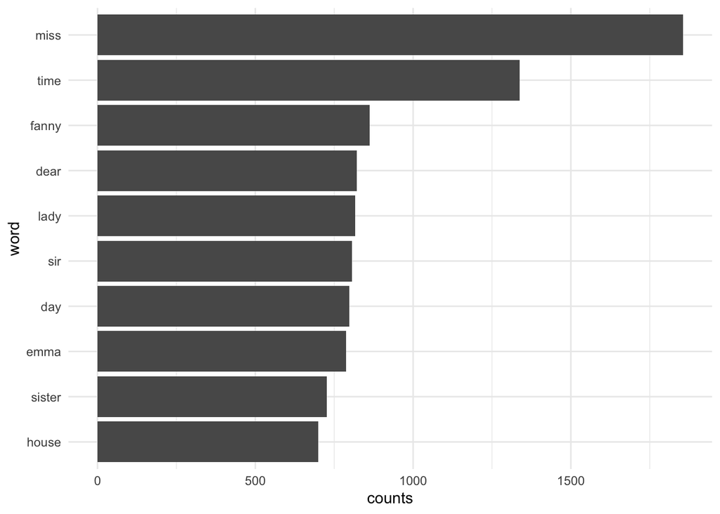

```r
# second image: ordered
ggplot(austen_top10, aes(x = n, y = fct_reorder(word, n))) +
  geom_col() +
  theme_minimal() +
  labs(x = "counts", y = "word")
```

## **Practice 1 (15 minutes):**

Run the script below then complete the script (see commented subsections on what to do)

```r
# Creates an R object called hgwells_data
# hgwells_data contains text data from the works of H.G. Wells' "The Time Machine"
library(gutenbergr)
hgwells_data <- gutenberg_download(c(35))
```

```
Determining mirror for Project Gutenberg from
https://www.gutenberg.org/robot/harvest.
Using mirror http://aleph.gutenberg.org.
```

```r
head(hgwells_data, 10)
```

```
# A tibble: 10 × 2
   gutenberg_id text
          <int> <chr>
 1           35 "The Time Machine"
 2           35 ""
 3           35 "An Invention"
 4           35 ""
 5           35 "by H. G. Wells"
 6           35 ""
 7           35 ""
 8           35 "CONTENTS"
 9           35 ""
10           35 " I Introduction"
```

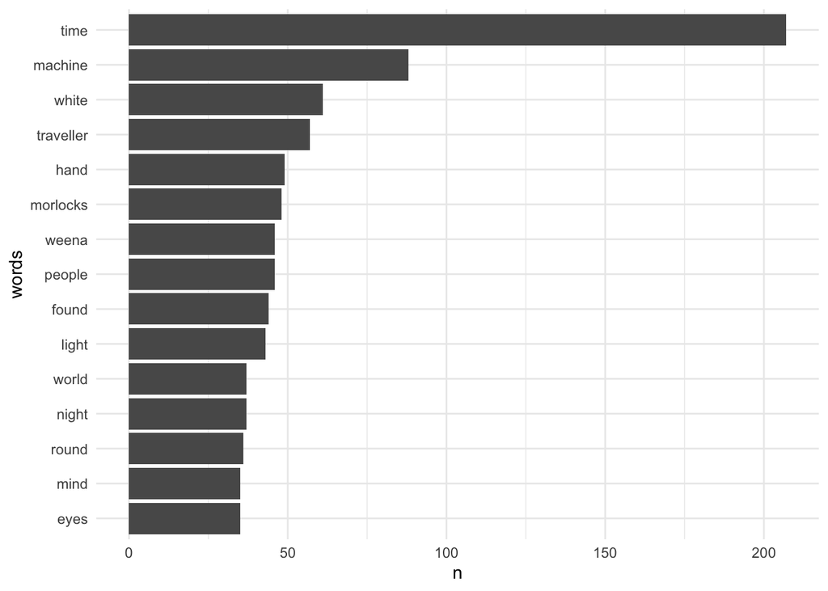

```r
# Tokenize hgwells_data and save the data frame into your R environment
hgwells_data_tidy <- hgwells_data |>
  unnest_tokens(output = word, input = text)

# Create a table or data frame that only includes the top 15 words (excludes stop words)
data("stop_words")

top15_hgwells <- hgwells_data_tidy |>
  anti_join(stop_words) |>
  group_by(word) |>
  summarise(n = n()) |>
  arrange(-n) |>
  head(15)
# Create an ggplot image that shows top 15 words visually
ggplot(top15_hgwells, aes(y = fct_reorder(word, n), x = n)) +
  geom_col() +
  labs(y = "words") +
  theme_minimal()
```

## Sentiment Analysis

Let’s address the topic of opinion mining or **sentiment analysis**.

When human readers approach a text, we use our understanding of the emotional intent of words to infer whether a section of text is positive or negative, or perhaps characterized by some other more nuanced emotion like surprise or disgust.

Of note, there is `inner_join()` between Tidy Text and Sentiment Lexicon.

## Detour: inner_join()

Let us revisit tableA and tableB but this time, we will use `inner_join()` instead of `anti_join()`. Let us run the next two R chunks:

```r
tableA <- tibble(word = c("A", "B", "C"))
tableB <- tibble(word = c("B", "D", "Z"))

tableA
```

```
# A tibble: 3 × 1
  word
  <chr>
1 A
2 B
3 C
```

```r
tableB
```

```
# A tibble: 3 × 1
  word
  <chr>
1 B
2 D
3 Z
```

You may think of `inner_join()` as the opposite of `anti_join()`. In `anti_join()`, we used it to remove words that were present in the `stop_words` data. In the example below, we keep elements from tableA that it shares with tableB only (so B is the only row printed):

```r
tableA |>
  inner_join(tableB)
```

```
# A tibble: 1 × 1
  word
  <chr>
1 B
```

**Detour complete!** Now let us go back to actual text analysis!

## Sentiment Analysis Lexicon

**What is a lexicon?** Think of it as a vocabulary or dictionary of specific words.

In the context of our word, you may think of sentiment analysis lexicon as a database of words that identify words with their respective sentiment in whatever scale they provide.

The tidytext package provides three lexicons we can leverage:

- `AFINN` from [Finn Årup Nielsen](http://www2.imm.dtu.dk/pubdb/views/publication_details.php?id=6010),
- `bing` from [Bing Liu and collaborators](https://www.cs.uic.edu/~liub/FBS/sentiment-analysis.html), and
- `nrc` from [Saif Mohammad and Peter Turney](http://saifmohammad.com/WebPages/NRC-Emotion-Lexicon.htm).

Let us preview the data that is provided across these three lexicons. But two of them require the installation of `textdata` beforehand so run this script in your console before moving forward (it doesn’t have to be loaded however):

> install.packages(“textdata”)

…

Now let us preview the afinn, bing, and nrc lexicon by running the scripts below:

**Important note before running the three scripts below:** If this is your first time running them, you might see additional prompt in your Console for two of the lexicons we will run. It will likely ask you type in 1 in your Console, then press Enter/Return from your key board. I will take a two-minute pause to allow you to run the next three scripts (and raise your hands if you cant see any print out):

```r
# afinn assigns words with a score that runs between -5 and 5, with negative scores indicating negative sentiment and positive scores indicating positive sentiment.
afinn_lexicon <- get_sentiments("afinn")

head(afinn_lexicon)
```

```
# A tibble: 6 × 2
  word       value
  <chr>      <dbl>
1 abandon       -2
2 abandoned     -2
3 abandons      -2
4 abducted      -2
5 abduction     -2
6 abductions    -2
```

```r
# assigns words with either 'negative' or 'positive'
bing_lexicon <- get_sentiments("bing")

head(bing_lexicon)
```

```
# A tibble: 6 × 2
  word       sentiment
  <chr>      <chr>
1 2-faces    negative
2 abnormal   negative
3 abolish    negative
4 abominable negative
5 abominably negative
6 abominate  negative
```

```r
# assigns each word with one of the 10 sentiments available
nrc_lexicon <- get_sentiments("nrc")

head(nrc_lexicon)
```

```
# A tibble: 6 × 2
  word      sentiment
  <chr>     <chr>
1 abacus    trust
2 abandon   fear
3 abandon   negative
4 abandon   sadness
5 abandoned anger
6 abandoned fear
```

```r
# shows which sentiments are available
nrc_lexicon |>
  group_by(sentiment) |>
  summarise(n = n())
```

```
# A tibble: 10 × 2
   sentiment        n
   <chr>        <int>
 1 anger         1245
 2 anticipation   837
 3 disgust       1056
 4 fear          1474
 5 joy            687
 6 negative      3316
 7 positive      2308
 8 sadness       1187
 9 surprise       532
10 trust         1230
```

```r
# this is extra: you don't need to know this but paste0() is something you really use in the real world
nrc_lexicon |>
  group_by(word) |>
  summarise(n = n(), sentiment = paste0(sentiment, collapse = ", ")) |>
  filter(n > 1)
```

```
# A tibble: 3,682 × 3
   word            n sentiment
   <chr>       <int> <chr>
 1 abandon         3 fear, negative, sadness
 2 abandoned       4 anger, fear, negative, sadness
 3 abandonment     5 anger, fear, negative, sadness, surprise
 4 abduction       4 fear, negative, sadness, surprise
 5 aberration      2 disgust, negative
 6 abhor           4 anger, disgust, fear, negative
 7 abhorrent       4 anger, disgust, fear, negative
 8 abject          2 disgust, negative
 9 abnormal        2 disgust, negative
10 abolish         2 anger, negative
# ℹ 3,672 more rows
```

There are a lot of methods to do sentiment analysis. But the ones we are doing are called **dictionary-based sentiment analysis.** Dictionary-based methods like the ones we are discussing find the total sentiment of a piece of text by adding up the individual sentiment scores for each word in the text.

Moreover, it important to note that not every English word is in the lexicons provided above because many English words are pretty neutral.

## **Use cases of the nrc lexicon**

Let us quickly revisit `austen_books_tidy` we created earlier:

```r
# properly saves the data as an R object in your R environment
austen_books <- austen_books()

# tokenize austen_books
austen_books_tidy <- austen_books |>
  unnest_tokens(output = word, input = text)

# prints a random sample of 10 rows
sample_n(austen_books_tidy, 10)
```

```
# A tibble: 10 × 2
   book                word
   <fct>               <chr>
 1 Emma                see
 2 Persuasion          smiles
 3 Mansfield Park      in
 4 Emma                passing
 5 Persuasion          know
 6 Sense & Sensibility overlooked
 7 Sense & Sensibility home
 8 Pride & Prejudice   must
 9 Pride & Prejudice   as
10 Emma                received
```

**Quick reminder:** `inner_join()` will only keep data or words when words are found in both tables. If we are interested in sentiment analysis, it should make sense why we want to use `inner_join()`–we essentially only want to keep words that have sentiments if we are doing an analysis on sentiments.

```r
# saves the nrc lexicon as an R object
nrc_lexicon <- get_sentiments("nrc")

# inner joined data between austen_books_tidy and nrc_lexicon
austen_nrc_joined <- austen_books_tidy |>
  inner_join(nrc_lexicon)
# Prints random sample from austen_nrc_joined
sample_n(austen_nrc_joined, 10)
```

```
# A tibble: 10 × 3
   book              word       sentiment
   <fct>             <chr>      <chr>
 1 Pride & Prejudice kind       joy
 2 Pride & Prejudice comfort    trust
 3 Persuasion        agreeable  positive
 4 Emma              feeling    joy
 5 Northanger Abbey  scarcely   sadness
 6 Persuasion        death      negative
 7 Mansfield Park    reform     positive
 8 Northanger Abbey  usual      positive
 9 Mansfield Park    deal       anticipation
10 Mansfield Park    remarkably positive
```

Reminder: there are 10 sentiments within nrc. Below tallies the nrc sentiments for all the books combined from `austen_nrc_joined`:

```r
austen_nrc_joined |>
  group_by(sentiment) |>
  summarise(n = n()) |>
  arrange(-n) # -n is a short cut notation for desc(n)
```

```
# A tibble: 10 × 2
   sentiment        n
   <chr>        <int>
 1 positive     42886
 2 trust        25206
 3 negative     21438
 4 anticipation 20830
 5 joy          18850
 6 sadness      10917
 7 fear         10843
 8 surprise      9180
 9 anger         7615
10 disgust       6086
```

Tallying nrc sentiments per book to get insight on theme/messaging of specific books:

```r
austen_nrc_joined |>
  group_by(book, sentiment) |>
  summarise(n = n()) |>
  arrange(book, -n) # -n is a short cut notation for desc(n)
```

```
# A tibble: 60 × 3
# Groups:   book [6]
   book                sentiment        n
   <fct>               <chr>        <int>
 1 Sense & Sensibility positive      7314
 2 Sense & Sensibility trust         4217
 3 Sense & Sensibility negative      3994
 4 Sense & Sensibility anticipation  3590
 5 Sense & Sensibility joy           3256
 6 Sense & Sensibility sadness       2062
 7 Sense & Sensibility fear          1861
 8 Sense & Sensibility surprise      1486
 9 Sense & Sensibility anger         1343
10 Sense & Sensibility disgust       1167
# ℹ 50 more rows
```

## Practice 2 (5 mins)

Complete the script below (run the script below first to remind yourself of the underlying data).

Next write an R script that will tally the top 20 words related to the `anticipation` as a sentiment from the book `Sense & Sensibility`. Then save this R object as `anticipate20` then print a sample using `head()`:

```r
# run this script and remind yourself
head(austen_nrc_joined)
```

```
# A tibble: 6 × 3
  book                word        sentiment
  <fct>               <chr>       <chr>
1 Sense & Sensibility sense       positive
2 Sense & Sensibility sensibility positive
3 Sense & Sensibility long        anticipation
4 Sense & Sensibility respectable positive
5 Sense & Sensibility respectable trust
6 Sense & Sensibility general     positive
```

```r
# your additional code below:
anticipate20 <- austen_nrc_joined |>
  filter(sentiment == 'anticipation') |>
  filter(book == 'Sense & Sensibility') |>
  group_by(word) |> # group_by(sentiment, book, word) is more descriptive
  summarise(n = n()) |>
  arrange(-n) |>
  head(20)

anticipate20
```

```
# A tibble: 20 × 2
   word            n
   <chr>       <int>
 1 time          239
 2 mother        213
 3 good          177
 4 thought       116
 5 long          104
 6 happy         100
 7 hope           88
 8 present        84
 9 letter         76
10 immediately    72
11 spirits        69
12 happiness      66
13 comfort        63
14 glad           44
15 marriage       44
16 engaged        42
17 child          39
18 expected       39
19 fortune        38
20 coming         37
```

## **afinn case uses:**

Again, afinn assigns words with a score that runs between -5 and 5, with negative scores indicating negative sentiment and positive scores indicating positive sentiment.

Here’s the output if we were to `inner_join()` `austen_books_tidy` with `afinn_lexicon`:

```r
afinn_lexicon <- get_sentiments("afinn")

merged_afinn <-  austen_books_tidy |>
  inner_join(afinn_lexicon)
head(merged_afinn)
```

```
# A tibble: 6 × 3
  book                word     value
  <fct>               <chr>    <dbl>
1 Sense & Sensibility engage       1
2 Sense & Sensibility good         3
3 Sense & Sensibility advanced     1
4 Sense & Sensibility death       -2
5 Sense & Sensibility great        3
6 Sense & Sensibility loss        -3
```

**What can you do with these numbers?** Add them up!

```r
merged_afinn |>
  group_by(book) |>
  summarise(sentiment_sum = sum(value))
```

```
# A tibble: 6 × 2
  book                sentiment_sum
  <fct>                       <dbl>
1 Sense & Sensibility          3310
2 Pride & Prejudice            3955
3 Mansfield Park               5548
4 Emma                         5837
5 Northanger Abbey             2188
6 Persuasion                   2823
```

“I think out of Austen’s works Emma was the most comical.” - a quote I saw in Reddit after discussing Austen’s work. It might be tied to the high sentiment sum seen in Emma above.

## **bing case uses:**

Again, bing assigns words with either a negative or a positive value.

```r
bing_lexicon <- get_sentiments("bing")

merged_bing <-  austen_books_tidy |>
  inner_join(bing_lexicon)
head(merged_bing)
```

```
# A tibble: 6 × 3
  book                word        sentiment
  <fct>               <chr>       <chr>
1 Sense & Sensibility respectable positive
2 Sense & Sensibility good        positive
3 Sense & Sensibility advanced    positive
4 Sense & Sensibility death       negative
5 Sense & Sensibility great       positive
6 Sense & Sensibility loss        negative
```

Not much we can do here. But tally the positive and negative words.

```r
merged_bing |>
  group_by(sentiment) |>
  summarize(n = n())
```

```
# A tibble: 2 × 2
  sentiment     n
  <chr>     <int>
1 negative  21679
2 positive  30608
```

```r
# book-specific sentiment analysis using bing
merged_bing |>
  group_by(book, sentiment) |>
  summarize(n = n())
```

```
# A tibble: 12 × 3
# Groups:   book [6]
   book                sentiment     n
   <fct>               <chr>     <int>
 1 Sense & Sensibility negative   3671
 2 Sense & Sensibility positive   4933
 3 Pride & Prejudice   negative   3652
 4 Pride & Prejudice   positive   5052
 5 Mansfield Park      negative   4828
 6 Mansfield Park      positive   6749
 7 Emma                negative   4809
 8 Emma                positive   7157
 9 Northanger Abbey    negative   2518
10 Northanger Abbey    positive   3244
11 Persuasion          negative   2201
12 Persuasion          positive   3473
```

## Creating a plot with both positive and negative top 10 words:

For this example, let us focus on `merged_bing` which looks like:

```r
head(merged_bing, 10)
```

```
# A tibble: 10 × 3
   book                word        sentiment
   <fct>               <chr>       <chr>
 1 Sense & Sensibility respectable positive
 2 Sense & Sensibility good        positive
 3 Sense & Sensibility advanced    positive
 4 Sense & Sensibility death       negative
 5 Sense & Sensibility great       positive
 6 Sense & Sensibility loss        negative
 7 Sense & Sensibility comfortably positive
 8 Sense & Sensibility goodness    positive
 9 Sense & Sensibility solid       positive
10 Sense & Sensibility comfort     positive
```

Now, let us identify the top words under both positive and negative sentiment (we will keep building on the code here and build on it to create a finalize code):

```r
# preliminary code
bing_lexicon <- get_sentiments("bing")

merged_bing <-  austen_books_tidy |>
  inner_join(bing_lexicon)
sentiment_tally <- merged_bing |>
  group_by(sentiment, word) |>
  summarise(n = n())
sentiment_tally
```

```
# A tibble: 2,585 × 3
# Groups:   sentiment [2]
   sentiment word           n
   <chr>     <chr>      <int>
 1 negative  abominable    17
 2 negative  abominably     7
 3 negative  abominate      3
 4 negative  abrupt         5
 5 negative  abruptly      12
 6 negative  absence      111
 7 negative  absurd        19
 8 negative  absurdity     12
 9 negative  abuse          8
10 negative  abused         6
# ℹ 2,575 more rows
```

Is there an easy way to subset the data above so it only keeps the top 10 for both negative and positive words at the same time? Yes, by using `slice_max()`

```r
# preliminary code
bing_lexicon <- get_sentiments("bing")

merged_bing <-  austen_books_tidy |>
  inner_join(bing_lexicon)
sentiment_tally <- merged_bing |>
  group_by(sentiment, word) |>
  summarise(n = n())
# this part right here tells R that you want the top 10 words for negative/position sentiment: creates a sentiment-specific top 10
top10_each_sentiment <- sentiment_tally |>
  group_by(sentiment) |>
  slice_max(n, n = 10)

top10_each_sentiment
```

```
# A tibble: 20 × 3
# Groups:   sentiment [2]
   sentiment word           n
   <chr>     <chr>      <int>
 1 negative  miss        1855
 2 negative  poor         424
 3 negative  doubt        281
 4 negative  object       233
 5 negative  sorry        219
 6 negative  impossible   215
 7 negative  afraid       198
 8 negative  bad          174
 9 negative  scarcely     174
10 negative  anxious      165
11 positive  well        1523
12 positive  good        1380
13 positive  great        981
14 positive  like         725
15 positive  better       639
16 positive  enough       613
17 positive  happy        534
18 positive  love         495
19 positive  pleasure     462
20 positive  happiness    369
```

Let us create a preliminary ggplot image geom_col() which we used earlier for the word count example earlier but we want to color code by sentiment and use facet_wrap() to create separate boxes for negative and positive emotions:

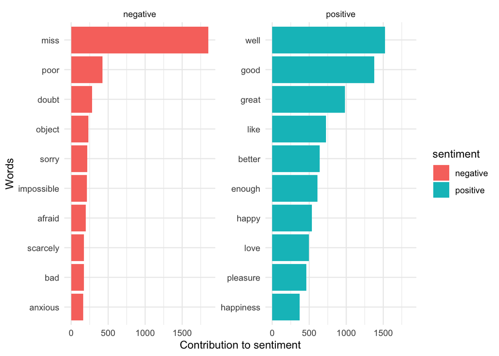

```r
# Finalized code
bing_lexicon <- get_sentiments("bing")

merged_bing <-  austen_books_tidy |>
  inner_join(bing_lexicon)
sentiment_tally <- merged_bing |>
  group_by(sentiment, word) |>
  summarise(n = n())
top10_each_sentiment <- sentiment_tally |>
  group_by(sentiment) |>
  slice_max(n, n = 10)

ggplot(top10_each_sentiment, aes(x = n,
                                 y = fct_reorder(word, n),
                                 fill = sentiment)) +
  geom_col() +
  facet_wrap(~sentiment, scales = "free_y") +
  labs(x = "Contribution to sentiment",
       y = "Words") +
    theme_minimal()
```

## Practice 3 (15 mins)

If we are pressed in time and skip this in class, this will be a homework problem 1 in the next homework.

As with Problem 1, complete the R script below. But your goal is to create a ggplot similar to what we just did above:

```r
# Creates an R object called hgwells_data
# hgwells_data contains text data from the works of H.G. Wells' "The Time Machine"
library(gutenbergr)
hgwells_data <- gutenberg_download(c(35))
head(hgwells_data, 10)
```

```
# A tibble: 10 × 2
   gutenberg_id text
          <int> <chr>
 1           35 "The Time Machine"
 2           35 ""
 3           35 "An Invention"
 4           35 ""
 5           35 "by H. G. Wells"
 6           35 ""
 7           35 ""
 8           35 "CONTENTS"
 9           35 ""
10           35 " I Introduction"
```

```r
# Tokenize hgwells_data and save the data frame into your R environment


# Load the bing lexicon into the R env't and then use inner_join() to create a new data frame into your R environment


# Create a table similar to the top10_each_sentiment data frame we created
# Call it hgwells_top10 for this example. Use slice_max(n, n = 10).


# Create an ggplot image that shows the top 10 words visually for both negative and positive sentiment
```

## **Creating Word Cloud For Top Words**

For this task, let us reuse `austen_books_tidy` and modify prior code we went over to create a data frame with a top 50 word table called `top50words`:

```r
top50words <- austen_books_tidy |>
  anti_join(stop_words) |>
  group_by(word) |>
  summarize(n = n()) |>
  arrange(desc(n)) |>
  head(50)
top50words
```

```
# A tibble: 50 × 2
   word       n
   <chr>  <int>
 1 miss    1855
 2 time    1337
 3 fanny    862
 4 dear     822
 5 lady     817
 6 sir      806
 7 day      797
 8 emma     787
 9 sister   727
10 house    699
# ℹ 40 more rows
```

For this task, we will be using the `wordcloud` package. Please install it using your console. **Note:** If there is not enough space, wordcloud will ignore your max.words specification.

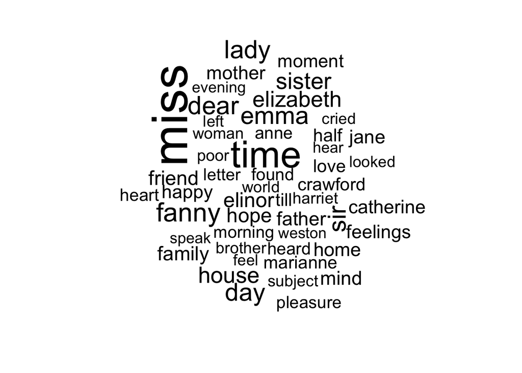

```r
# run this if not installed:
# install.packages("wordcloud")
library(wordcloud)
# Note: We did this in the first day of lecture
# But $ tells R you want you use the variable from the specifed data frame to the left of the $ sign.
wordcloud(words = top50words$word,
          freq = top50words$n,
          max.words = 50)
```

## Practice 4 (3 mins)

Use `hgwells_data` from Practice 1 to create a word tally table. Then using that table, use `wordcloud()` to produce a word cloud.

```r
# Your code below
```